# Modular Model Building

A Vignette

David L Smith, Sean L Wu

2023-01-31

$\otimes$ | hub | map | model building

## $\odot$

One of the great strengths of mathematical models is that they lend structure and rigor to the analysis of complex systems. One kind of complex system involving mosquito ecology and malaria epidemiology, transmission dynamics, and control is of great interest because malaria is a major cause of human disease and suffering. If we want to give robust, evidence-based advice about malaria policy, we must grapple with the complexity. Policy advice to countries, acknowledging budget limitations, supports two goals: to reduce the burden of malaria; and to set the stage for malaria elimination.

While there are some common themes that unify the study of complex systems, we are primarily interested in problems related to malaria and malaria policies – and perhaps other mosquito-transmitted pathogens – so we want to *apply* tools and approaches that have been used in the study of other complex systems. In this case, we think about malaria as a dynamical system. To deal with the complexity of malaria, we surveyed more than one century of efforts, and we developed a framework for building mathematical models that could help us to understand malaria and other mosquito-transmitted diseases [1]. The simulation software is called `exDE` and `MicroMoB.` An interface for model building has been incorporated into setup functions that are part of the the core software. An umbrella package Satellite and is called `mob_setup.` The work is done through a set of wrappers that execute tasks, called `mob_work.`

This vignette in the `RAMP-Model-Library` is the first in a series. It is designed to introduce the concept of modularity. We will also introduce some notation that we will use to describe the structure of the framework, and the way it was implemented. We introduce some concepts that will provide some context for the User Interface, which includes a set of case studies and highlight its capabilities as a tool to support robust policy analytics for malaria policy.

If we want to use models to extend our ability to use reason to address complex issues in malaria, we need a way of building and analyzing models quickly and efficiently based on a synthesis of available evidence. If the processes are reasonably well understood, it should be fairly easy to imagine a model, implement it and examine outputs, modify it to devise a test, and readily compare model outputs. This process of *model building* involves many related tasks: development and refinement of basic concepts, development of equations or algorithms, numerical methods, programming, verification, debugging, and so on. That list of tasks would unpack the many ways we use the terms *model* and *model building* to describe several different but closely related activities. To analyze complex systems, all of these tasks *must* be done well and in order, but it is easy to get bogged down in the technical details of any one task. Software that could support and enable analysis of complex systems would have already identified and tackled many of those technical challenges. It *should* be possible to take the best elements of any models and combine them. It would be nice to know that we could push some of those models to the extreme, if we wanted to. The software should enable model building for analytics. For the end user we have in mind, the technical challenges and the mathematics should become almost invisible.

This vision imagines that there is already a sophisticated toolbox ready to model malaria epidemiology, transmission dynamics, and control. While a rich set of models and concepts does exist, it is scattered across *ad hoc* studies [2], or implemented in individual-based models (Figure 1). The innovative concepts, ideas, and algorithms in those studies *should* be inter-operable, but making them work together is not as easy as it seems. Models developed by experts who work in different academic sub-disciplines – models of mosquito ecology, malaria epidemiology, and vector control – tend to be difficult to combine, and there were some enormous gaps in describing spatial dynamics, exogenous forcing, and integrated vector control [3].

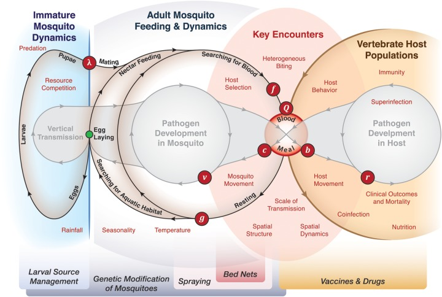

**Figure 1:** A diagram of malaria models from a systematic review [2,3]

All this motivated the design of `exDE` and `MicroMoB` as tools that could streamline the process of building models fit for purpose. How could we build a modular framework that was truly plug-and-play? How could we guarantee flexibility in the structural design and mathematical consistency at the same time? The only way to really make this work would be to build a framework with *rigid* interface that could connect models while guaranteeing mathematical consistency. At the same time, we identified key processes that should be modifiable to accommodate various studies. We wanted it to be *flexible.* To build this, we took the systems apart and reassemble them in a way that worked conceptually, that connected the biology, that was mathematically sound, and that worked computationally.

The design of `exDE` is explained in a set of vignettes, available on [github](https://dd-harp.github.io/exDE/). Those vignettes walk through the process of setting up models, but those vignettes were not written for the end user we have in mind here. In those vignettes, many of the setup tasks get repeated. They are part of the stiff interface that makes modular computation possible. We imagine anyone with the time and skills could write down many of these models by following those pages, but errors could be introduced in the implementation. Why not streamline model building by automating these setup tasks to make them as error free as possible?

To set up a study, a user should already *understand* models and modeling reasonably well. The supporting concepts and theory, and the software are developed well enough to support a streamlined setup process. For analytics, then endpoint of setup is a model that serves as a starting point for a study – call it a *study prototype.* It need not be perfect. We assume models will go through several iterations and be subjected to intense scrutiny before any outputs get translated into policy advice. Before giving advice, the model parameters should be modified to accurately describe the dynamics, but if we assume that the relevant parameter values will be subjected to scrutiny and change in the model fitting process, why not start with some reasonable *default* choices for the parameters? The user interfaces we developed make many of the choices for the end user. They *should* be modified, and the interface makes this easy under the assumption that the model will undergo further development. To serve these ends, we also provide *IO* routines to read and write models.

From this point of view, `exDE` is a toolbox for someone who wants to *use* models to understand malaria and give advice. The software has built-in functionality for spatial dynamics in structured populations with exogenous forcing by weather and vector control.

(click on the next tab, **Modularity**)

## Modularity

Ross developed the first models for the transmission dynamics of malaria. In 1911, that model was presented as a set of two coupled differential equations. The equations described parasite infections in humans and mosquitoes (see Figure 1) [4,5]. The models and the underlying concepts guided development of a broader theory of transmission that included metrics to measure transmission [5].

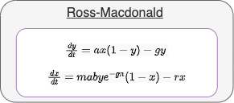

**Figure 1:** An example of a Ross-Macdonald model. For a longer introduction, please see [5]. (The open access article is available at [PLoS Pathogens](https://journals.plos.org/plospathogens/article?id=10.1371/journal.ppat.1002588).)

Starting around 1970, academics began to elaborate on the simple models. The equations developed by Ross, Macdonald, and others from 1908-1969 were a starting point for studies of the dynamics and control of malaria or other mosquito-borne pathogens [2]. In that study, we noted that *most* studies deviated from the assumptions of the Ross-Macdonald model in one or two different ways. The exception was individual-based simulation models that tended to embrace the full complexity. These models were developed to serve policy needs, so they needed to be realistic enough to address a large set of concerns all-at-once. The models thus tended to deviate from the Ross-Macdonald model in several ways.

We started with a classical Ross-Macdonald model (Figure 1), but we found it was difficult to extend when the variables were *proportions,* so we changed the variables to densities. We wanted to deal with mosquito ecology, so we added adult mosquito popultion dynamics, and we coupled the adult populations to immature mosquito populations in aquatic habitats (Figure 2). The extended Ross-Macdonald model had all the right parts. The four equations in this model each represented a different part of the whole system that could be isolated and elaborated upon.

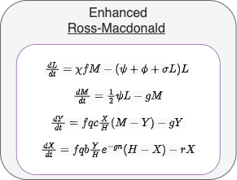

**Figure 2:** The Ross-Macdonald model, extended to include mosquito ecology. The dynamics of infections in humans are from Ross and Lotka [5]; the equations describing adult mosquito dynamics were developed by Aron & May [6]; and the equation for larval dynamics was published later by some of the authors of this document [7].

We then pulled the equations apart and rewrote them, so that each equation had one (or more) input term from another equation, and an internal dynamic (Figure 3.)

The first two equations thus describe mosquito ecology and population dynamics, connected by egg laying and emergence. The second two equations described parasite infection dynamics in mosquitoes and in humans connected through transmission during blood feeding. In this form, we can also identify some important constraints – the model describing parasite infection dynamics in mosquitoes *must* extend the model describing mosquito ecology. (They are inevitably implemented together.)

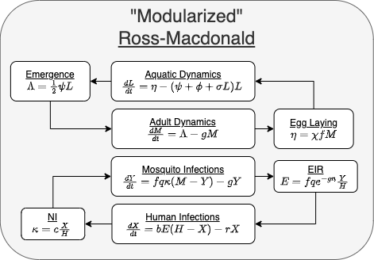

**Figure 3:** The system in Figure 2, rewritten in a form that emphasized the modular nature of these systems.

To make this **modular,** we wanted to be able to substitute other model families – alternative systems of equations – in place of these. This meant thinking about each component as a representative member of a class of models. We wanted to add spatial dynamics with structured aquatic habitats. We wanted to be able to stratify the human populations. Since the model structure could vary, we needed the interface to be generic – how would we fit together any set of dynamical components? If we wanted maximum flexibility, we had to be careful to define what was required of each dynamical component as an output – something that would be an input to another component – and think about the process. One process was egg laying through a process of searching for habitats and selection. One process was emergence. The other two processes – parasite transmission – occurred through mosquito blood feeding.

In the general system, we thus formalized this by naming the quantities that would come out of one model, the processes required by another model, and then developing algorithms to connect them.

- Aquatic mosquito dynamics were defined by a state space, $\cal L$, and $d{\cal L}/dt = \eta + F_{\cal L}({\cal L})$. A function describes emerging mosquitoes, $\alpha = F_\alpha ({\cal L})$.
- Adult mosquito dynamics were defined by a state space, $\cal M$, and $d{\cal M}/dt = \Lambda + F_{\cal M}({\cal M})$. A function describes eggs laid, $\nu = F_\nu({\cal M})$.
- Parasite infection dynamics in mosquitoes were defined by a state space, $\cal Y$, and $d{\cal Y}/dt = F_{\cal Y}(\kappa, {\cal M}, {\cal Y})$. A function would describe the density of infectious, blood feeding mosquitoes, $Z=F_Z({\cal Y})$.
- Parasite infection dynamics in humans were defined by a state space, $\cal X$, and $d{\cal X}/dt = F_{\cal X}(E, {\cal X}, {\cal H})$. A function would describe the effective infectious density of humans, $X=F_X({\cal X}, {\cal H})$.

For mosquito ecology, egg-laying and emergence were a *local* process, so we needed to know the patch membership of each habitat (defined by a matrix, $\cal N$).

- Emergence would aggregate adults from each habitat up to the mosquito population: $\Lambda = F_\Lambda(\alpha)$. In most cases, this is a simple sum that uses the membership matrix, so $\Lambda = \cal N \cdot \alpha$
- Egg laying would describe how eggs laid by adult mosquitoes were distributed among habitats. Since the eggs are passed from adults to habitats, function would use the transpose membership matrix, ${\cal N}^T$. Egg deposition would depend on egg laying, and perhaps other factors related to adult mosquito search for habitats: $\eta = F_\eta({\cal N}^T, \nu, \ldots).$

For parasite transmission, we needed an algorithm to describe blood feeding. This interface involved an *interaction* between two kinds of agents, so it was much more involved; the algorithm would need to account for time spent, mosquito circadian patterns, mosquito blood feeding rates and habits, heterogeneous availability of hosts, and heterogeneous exposure. For mathematical consistency, we needed to reconfigure the functions describing blood feeding rates and habits, and a matrix ($\beta$) that would describe how biting by mosquitoes would get distributed among humans. To do so, we relied on an important emerging concept in mosquito ecology – resource availability [8–11]. The model of blood feeding would need to guarantee mathematical consistency, and in the end:

- The EIR for each human population stratum would be computed as a function of the density of blood feeding, infectious mosquitoes: $Z = F_Z({\cal Y})$ and $E = \beta\cdot fqZ$
- The net net infectiousness would be computed as a function of the effective infectious density of all the human: $X = F_X({\cal X}, {\cal H})$ and $\kappa = \beta^T \cdot X$

In this generalized modular form, we have a system with four dynamical components. Conceptually, this is how the framework works.

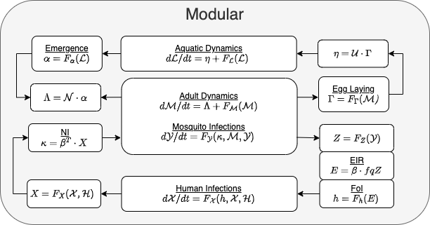

**Figure 4**: In generalized notation, the modular framework is summarized by this diagram.

## A Framework

While the concepts and principles (above) motivated the overall design of the framework, we still had to develop and implement the algorithms without restricting functionality. We wanted to be able to handle model features: spatial dynamics of adult mosquito populations with moving humans and mosquitoes; generalized measures of connectivity through travel, including exposure to parasite (and mosquito) populations outside an area of study; mosquito search and egg-laying in structured – and possibly ephemeral – habitats for aquatic mosquito population dynamics; stratification of human populations, with methods for dealing with age and time; heterogeneous spatial dynamics of mosquito populations, including movement; a generalized model for human heterogeneous exposure to the bites of infectious mosquitoes that would include environmental heterogeneity and translate *average* exposure into a form that would be consistent with mosquito catch counts data; models that were capable of dealing with integrated vector control; and complex temporal dynamics through exogenous forcing by weather ($\cal W$), vector control ($\cal V$), and possibly other factors.

To get all this to work right, we found that it was impossible to imagine that the parameters describing some aspects of mosquito behavior were constant – if they could be modified by vector control, then they must already differ because resource availability was heterogeneous. We borrowed the notion of a search for resources [12], codified and extended a concept of availability, used functional responses, and developed a model for adult mosquito behavior that was internally consistent. The concept of resource availability helped us frame the algorithms describing egg-laying and blood-feeding, and it also helped us frame a new model for mosquito search based on a concept of search and movement in relation to resource availability. Most importantly, the concept was *extensible,* ready for modification by weather and vector control.

We went through a similar process to think through the process of *stratifying* the human population.

We published a manuscript describing the modular framework, spatial dynamics, and spatial analysis [1]. Manuscript describing temporal dynamics and a generalized theory of vector control are planned. The framework, with added functionality, has now been implemented in `exDE`.

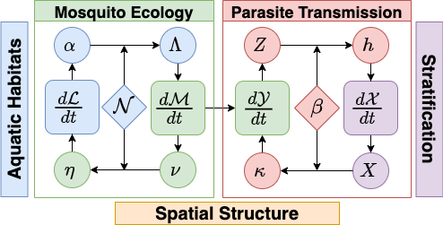

**Figure 5**: A diagram of the framework, as described in [Spatial Dynamics of Malaria Transmission](https://www.medrxiv.org/content/10.1101/2022.11.07.22282044v1)

The final steps were to develop software that could implement the framework and implement the software with algorithms that could streamline the process of setting up and running models.

In the current form, the framework has been extended to include exogenous forcing by weather ($\cal W$) and vector control ($\cal V$), and to include demographic changes (in $d {\cal H}/dt$). In compact form, there are now five core dynamical components:

- Aquatic dynamics, defined by a state space, ${\cal L}$, with dynamics described by the derivatives, $F_{\cal L}.$ The main input is deposition rates, $\eta.$
- Adult ecology, defined by a state space, ${\cal M},$ and dynamics described by the derivatives, $F_{\cal M}.$ The main input is adult mosquito emergence, ${\cal \Lambda}.$
- Parasite infection dynamics in mosquitoes, defined by a state space, ${\cal Y}$, and dynamics described by the derivatives, $F_{\cal Y}$, the main input is the net infectiousness of humans, $\kappa$.
- Parasite infection dynamics in humans, defined by a state space, ${\cal X}$, and dynamics described by the derivatives function, $F_{\cal X}$, the main input is the FoI, $h$.
- Human demographic change, defined by a state space, ${\cal H}$, and dynamics described by the derivatives function, $F_{\cal H}$

The dynamics are forced by exogenous variables describing weather, $\cal W$, vector control coverage, $\cal V$; and a set of variables describing resource availability, ${\cal R}$. The system is also *forced* by exogenous terms describing resource availability. In concise form, the dynamics look like this:

$$\begin{equation}
\begin{array}{rl}
d{\cal L}/dt &= \eta + F_{\cal L} \left({\cal L}, {\cal W}, {\cal
V}, {\cal R} \right) \\
d {\cal M}/dt &= \Lambda + F_{\cal M} \left({\cal M}, {\cal W},
{\cal V}, {\cal R}\right) \\
d {\cal Y}/dt &= F_{\cal Y} \left(\kappa, {\cal M}, {\cal Y}, {\cal
W}, {\cal V}, {\cal R} \right) \\
d {\cal X}/dt &= F_{\cal X} \left(h, {\cal X} \right) + F_{\cal H}
\left({\cal X}, {\cal H} \right)\\
d {\cal H}/dt &= F_{\cal H} \left({\cal X}, {\cal H} \right) \\
\end{array}
\label{calLMYX}
\end{equation}$$

The number and arrangement of patches and habitats can take any form, described by a patch membership matrix, $\cal N$. The dynamical components describing mosquito ecology are linked by well-defined terms:

- The emerging adults, $\alpha$, defined by a function $F_\alpha\left({\cal L}\right)$, are added to the adult populations in a patch, $\Lambda$, using a matrix describing membership, ${\cal N}$.
- The eggs laid by adults, $\Gamma$, defined by a function $F_\Gamma\left({\cal M}\right)$ are distributed among aquatic populations, $\eta$, using a matrix $\cal U$ (derived from the membership matrix transpose, ${\cal N}^T$, and a set of *habitat search weights,* $\omega_\nu$, describing habitat availability):

$$\begin{equation}
\begin{array}{rcl|rcl}
F_\alpha \left( {\cal L} \right) &\rightarrow & \alpha &
{\cal N} \cdot \alpha &\rightarrow& \Lambda \\
F_\nu \left( {\cal M} \right) &\rightarrow& \nu & {\cal
U}\left({\cal N}^T, w_\nu \right) \cdot \nu &\rightarrow& \eta
\\
\end{array}
\label{EcologyTerms}
\end{equation}$$

The dynamical components describing parasite transmission are linked by well-defined algorithm describing blood feeding, $\cal B$.

- Human availability to mosquitoes for blood feeding, $W$, is computed from the concept of **time at risk** ($\Psi$), human population densities $H=F_H({\cal H})$, and search weights, $w_f$.
- A term is supplied to the model that describes other available hosts, $O$, so that total available hosts are $B=W+O$.
- The mosquito population’s blood feeding rate, $f$, is a function of total available hosts, $f=F_f(B)$.
- The human fraction, $q$, is a function of the total available hosts, $q=F_q(W, B)$.
- Availability and time at risk are used to compute the matrix, $\beta$, describing how biting by mosquitoes is distributed among hosts.

With this blood feeding algorithm well-defined, we are in a position to describe the terms describing parasite transmission from mosquitoes to humans:

- The blood feeding model, $\cal B$ takes information about the availability of humans (including search weights, $w_f$ and time at risk $\Psi$), other blood hosts, and mosquito preferences, and it computes:
  - the blood feeding rate, $f$
  - the blood feeding fraction, $q$
  - the mixing matrix, $\beta$
- The density of blood feeding, infectious mosquitoes, $Z$, defined by a function $F_Z\left(\cal Y \right)$
- Blood meals by mosquitoes in patches are distributed among availabile humans in strata by a mixing matrix, $\beta$.
- The EIR for the strata, $E$, is defined by $\beta \cdot fqZ$
- The FoI for the patch is a function of the EIR, $h=F_h(E)$, which could include parameters or terms describing pre-erythrocytic immunity or environmental heterogeneity;

- The effective density of infectious humans, $X$, is defined by a function $F_X\left({\cal X}, {\cal H}\right)$:
  - a function from $\cal X$ comptues the expected probability an individual in the stratum would get infected, if bitten: $F_x(\cal X) \rightarrow x$,
  - the total density of the stratum, $F_H(\cal H) \rightarrow H$
  - $X = xH$.
- The net infectiousness of humans to mosquitoes in a patch, $\kappa$, is defined $\beta^T \cdot X$. For direct comparison, the FoI for the blood-feeding mosquito population (computed inside $d {\cal Y}/dt$) is $fq \kappa.$

In concise form:

$$\begin{equation}
\begin{array}{c|c|c|c}
{\cal B}(\ldots) \rightarrow \left\{ f, q, \beta \right\} & F_Z
\left( {\cal Y} \right) \rightarrow Z & \beta \cdot fqZ \rightarrow
E & F_h(E) \rightarrow h \\
F_X \left( {\cal X} \right) \rightarrow x &
F_H \left( {\cal H} \right) \rightarrow H & X = xH &
\beta^T \cdot X \rightarrow \kappa \\
\end{array}
\label{TransmissionTerms}
\end{equation}$$

With dynamically changing resources, we must develop dynamical components that translate changes in variables describing exogenous forcing factors into effects on parameters. These are implemented in a model-specific way. These concepts and the notation constitute the core framework.

There are a few interesting side cases that are not handled by this general description above. Of great importance for understanding malaria connectivity is malaria importation through travel and visitors, and perhaps through immigration of infective mosquitoes. This was omitted here, but it has been developed and described in [Spatial Dynamics of Malaria Transmission](https://www.medrxiv.org/content/10.1101/2022.11.07.22282044v1)

There are two other side cases:

- Endectocides are drugs transmitted in blood (like parasites) that affect parasite development in mosquitoes after exposure.
- Auto-disseminated larvicides are consumed by mosquitoes during sugar feeding that *treat* the habitats during egg laying.

The framework can deal with these special cases, but they have not yet been implemented.

## 4 - Next Steps

While the capabilities and complexity of the framework might seem overwhelming, the UI manages most of the steps and provides simple wrappers.

The Ross-Macdonald model is a great starting point, and a set of vignettes introduce the core concepts in order. The model assumes the user has a familiarity with malaria epidemiology.

To set up a model in `exDE,` the end user builds a model by making a set of choices:

- Setup requires a base model family by name from the catalog to fill each one of the five roles, but since ${\cal M}$ and ${\cal Y}$ are implemented together, this involves four model names: `Lname`, `MYZname`, `Xname`, and `Hname.`
- The user must set parameter values for all the dynamical components.
- The user must supply some information about the structural elements, including the number of patches, habitats, and strata. In fact, there are three choices:
  - How many patches are there?
  - Where are the aquatic habitats located? The user supplies a vector that describes the patch membership for each habitat.
  - How many human population strata are there, and where do they live? The user supplies a vector describing the residence patch of each stratum.
- If there is more than one patch, the user must supply some information about how humans and mosquitoes move around.
- How will the model deal with travel malaria and visitors?
- The user must also decide how to implement exogenous forcing, which changes the way the models are parameterized.
- What forms of vector control are being used?
- The user must decide how to set initial values for the variables.
- The user must decide how long to run the model and how often it should produce outputs.

The UI starts simple, and most of the setup steps have also been dramatically simplified. For example, the UI sets default values for all the parameters.

A good next step is to ready the document RAMP-ui.

## References

1.

Wu SL, Henry JM, Citron DT, Mbabazi Ssebuliba D, Nakakawa Nsumba J, Sánchez C. HM, et al. Spatial Dynamics of Malaria Transmission. 2022. Available: http://medrxiv.org/content/early/2022/11/15/2022.11.07.22282044.abstract

2.

Reiner RC Jr, Perkins TA, Barker CM, Niu T, Chaves LF, Ellis AM, et al. A systematic review of mathematical models of mosquito-borne pathogen transmission: 1970-2010. J R Soc Interface. 2013;10: 20120921.

3.

Smith DL, Perkins TA, Reiner RC Jr, Barker CM, Niu T, Chaves LF, et al. Recasting the theory of mosquito-borne pathogen transmission dynamics and control. Trans R Soc Trop Med Hyg. 2014;108: 185–197. doi:10.1093/trstmh/tru026

4.

Ross R. Some quantitative studies in epidemiology. Nature. 1911;87: 466–467.

5.

Smith DL, Battle KE, Hay SI, Barker CM, Scott TW, McKenzie FE. Ross, Macdonald, and a theory for the dynamics and control of mosquito-transmitted pathogens. PLoS Pathog. 2012;8: e1002588. doi:10.1371/journal.ppat.1002588

6.

Aron JL, May RM. The population dynamics of malaria. In: Anderson RM, editor. The Population Dynamics of Infectious Diseases: Theory and Applications. Boston, MA: Springer US; 1982. pp. 139–179. doi:10.1007/978-1-4899-2901-3_5

7.

Smith DL, Perkins TA, Tusting LS, Scott TW, Lindsay SW. Mosquito Population Regulation and Larval Source Management in Heterogeneous Environments. PLOS ONE. 2013;8: e71247. doi:10.1371/journal.pone.0071247

8.

Killeen GF, McKenzie FE, Foy BD, Bøgh C, Beier JC. The availability of potential hosts as a determinant of feeding behaviours and malaria transmission by African mosquito populations. Trans R Soc Trop Med Hyg. 2001;95: 469–476. doi:10.1016/s0035-9203(01)90005-7

9.

Ma BO, Roitberg BD. The role of resource availability and state-dependence in the foraging strategy of blood-feeding mosquitoes. Evol Ecol Res. 2008;10: 1111–1130. Available: http://www.evolutionary-ecology.com/abstracts/v10/2387.html

10.

Yakob L. How do biting disease vectors behaviourally respond to host availability? Parasit Vectors. 2016;9: 468. doi:10.1186/s13071-016-1762-4

11.

Thongsripong P, Hyman JM, Kapan DD, Bennett SN. Human-mosquito contact: A missing link in our understanding of mosquito-borne disease transmission dynamics. Ann Entomol Soc Am. 2021;114: 397–414. doi:10.1093/aesa/saab011

12.

Wu SL, Sánchez C HM, Henry JM, Citron DT, Zhang Q, Compton K, et al. Vector bionomics and vectorial capacity as emergent properties of mosquito behaviors and ecology. PLoS Comput Biol. 2020;16: e1007446. doi:10.1371/journal.pcbi.1007446